#### Link to our video :

https://drive.google.com/drive/folders/1jcqeiG_tf9A1wmg7-C4jR5qnEsw8omCi?usp=sharing

# Game's Gone: An analysis of Football Refereeing Bias in the Men's UEFA Champions League over the years.

# Permissions

Place an `X` in the appropriate bracket below to specify if you would like your group's project to be made available to the public. (Note that student names will be included (but PIDs will be scraped from any groups who include their PIDs).

- [ `X` ] YES - make available
- [ ] NO - keep private

# Names

- Yash Tandon
- Madhav Singhvi
- Aubai Miralam
- Abhyuday Singh
- Mitra Sutar

# Abstract

As long time football fans, we set out to explore whether the introduction of the Video Assistant Referee (VAR) in 2018 has actually reduced referee bias in the UEFA Champions League. Referee bias, particularly the concept of home field advantage, has long been debated in professional football. Although VAR was intended to make officiating more objective, it remains unclear how much it has actually changed patterns in disciplinary decisions. Our project investigates whether home teams still benefit from favorable decisions after the introduction of VAR and how these patterns have evolved over time.

Our findings indicate that referee behavior has shifted in the post VAR era, with red cards and fouls becoming more evenly distributed between home and away teams. However, yellow cards remain a persistent source of imbalance—home teams continue to receive fewer yellow cards even after adjusting for contextual variables. While VAR has helped reduce some aspects of officiating bias, it does not appear to fully eliminate long standing disparities.

Overall, our results suggest that VAR is a positive step toward fairness in football, but it is not a complete solution. Human judgment still plays a significant role in refereeing, and deeper systemic factors may continue to influence decisions on the pitch.

# Research Question

Here is our research question:

"After accounting for match context, has refereeing bias in the annual UEFA Champions League tournament, measured by indicators such as fouls conceded, cards received, and penalties awarded, decreased for home teams following the introduction of the Video Assistant Referee (VAR) in 2018, compared to the period before its implementation?"

## Background and Prior Work

Refereeing bias in football has been a very contentious topic in the public sphere, particularly in renowned competitions like the UEFA Champions League. A well-established phenomenon of refereeing bias is “home-field advantage”, where home teams generally receive more favorable judgments by the referees, whether due to crowd influence, implicit psychological bias, or institutional norms. A study by Buraimo, Forrest, and Simmons analyzing over six seasons of top English and German leagues found that home teams were less likely to receive yellow and red cards as opposed to their away counterparts. Using the bivariate probit model of in-games events, they found compelling evidence of referee bias even after controlling for match context(e.g., scoreline, stage of the tournament, team reputation, and in-game events)<sup>1</sup>. Since the Video Assistant Referee (VAR) was introduced in major competitions, researchers have attempted to surmise whether biases still exist. VAR involves a team of officials studying different angles of a suspected foul to assist the on-field referee in real-time. While VAR aims to bring greater objectivity and consistency, its use is limited to certain situations and still relies on human interpretation, leaving room for subjectivity. A Large cross-league analysis of more than 7,000 matches across 16 countries between 2009 and 2019 found that VAR had almost no impact on “home-field advantage”. While some metrics like offsides and yellow cards decreased, there was no significant improvement in bias-related outcomes such as penalties or overall team discipline<sup>2</sup>.

The COVID-19 pandemic, as devastating as it was, provided a rather unique opportunity to study the dynamics of sporting events. Matches played without fans attending, often referred to as “ghost games,” provided exceptional opportunities to isolate the influence of on-site supporters. Studies across Europe revealed that fanless games not only diminished but, for some, completely reversed the home-field advantage bias. For instance, Sors et al demonstrated that during the 2020 season, with attendance restrictions in place, seemed to significantly weaken both home-team advantage and referee bias <sup>4</sup>. In the same vein, Wunderlich et al. noted that while home teams continued to experience some performance advantage, under referee decision making, crowd influence nullified bias and ultra-supportive dominance shifted to neutral decision making<sup>5</sup>. This phenomenon was also shown in another study published in the Journal of Behavioral and Experimental Economics where absence of spectators resulted in an increased impartiality of referees devoid of social or coercive pressure to favor the home team<sup>6</sup>. Also, bias on the referee’s side is not only restricted to the home-field advantage. A study conducted on the Norwegian Premier League in 2020 investigated whether certain referees were prone to favor more popular or historically successful teams and to what degree they exhibited bias. Through video analysis and independent expository review panels, the study demonstrated that referees were biased within the context of penalty calls, reinforcing the argument that reputation and context profoundly impact decisions and remain potent forces, even in the VAR era<sup>3</sup>. By building on these lines of inquiry, this project seeks to examine whether home teams in the UEFA Champions League have continued to benefit from favorable refereeing decisions in the post-2018 VAR era—particularly in metrics like fouls conceded, cards received, and penalties awarded—while carefully considering the confounding influences such as our pandemic “ghost games”.

1. ^. Buraimo, B., Forrest, D., & Simmons, R. (2010). The 12th Man? Refereeing Bias in English and German Soccer. Journal of the Royal Statistical Society: Series A, 173(2), 431–449.
2. ^. Abbate, C., Cross, J., & Uhrig, R. (2024). Video assistant referee and home field advantage: Implications for referee bias. Southern Economic Journal, 91(11).
3. ^. Erikstad, M. K., & Johansen, B. T. (2020). Referee Bias in Professional Football: Favoritism Toward Successful Teams in Potential Penalty Situations. Frontiers in Sports and Active Living, 2, 19.
4. ^. Sors, F., Lourido, D., & Parisi, D. (2022). A complete season with attendance restrictions confirms the relevant contribution of spectators to home advantage and referee bias in association football. PeerJ, 10, e13681.
5. ^. Wunderlich, F., Weigelt, M., & Memmert, D. (2021). How does spectator presence affect football? Home advantage remains in European top-class football matches played without spectators during the COVID-19 pandemic. PLOS ONE, 16(3), e0248590.
6. ^. Reade, J. J., Schreyer, D., & Singleton, C. (2021). Echoes: The effects of crowd noise on refereeing decisions in football. Journal of Behavioral and Experimental Economics, 93, 101669.

# Hypothesis

We hypothesize that since the introduction of VAR in 2018, refereeing bias in favor of home teams in the UEFA Champions League has decreased, but not necessarily been eliminated. After accounting for match context, we expect that home and away teams will concede a more similar number of fouls, receive closer numbers of yellow and red cards, and be awarded penalties at more comparable rates than in the pre-VAR era.

This hypothesis assumes that VAR has helped reduce referee subjectivity by introducing video review for key decisions, thereby limiting—but not completely removing—the influence of home-field dynamics such as crowd pressure or implicit bias. Because VAR only intervenes in select situations (e.g., goals, penalties, red cards, but not yellow cards) and still involves human judgment, some degree of bias may persist.

# Data

## Data overview

We are using two datasets sourced from FBRef.com, covering matches in the UEFA Champions League. These datasets allow us to compare referee decision patterns before and after the implementation of VAR in 2018.

Before tidying the dataframes, here is the information of the two datasets we are working with:

- Dataset #1
  - Dataset Name: FBRef's Match Reports for Men's UEFA Champions League games from 2017/2018 to 2024/2025 seasons
  - Link to the dataset (this links it to where the respective seasons were scraped from, our R script is provided in the following section): https://fbref.com/en/comps/8/history/Champions-League-Seasons
  - Number of observations: 1057
  - Number of variables: 19

- Dataset #2
  - Dataset Name: FBRef's Match Reports for Men's UEFA Champions League games from 1999/2000 to 2016/2017 seasons
  - Link to the dataset (this links it to where the respective seasons were scraped from, our R script is provided in the following section): https://fbref.com/en/comps/8/history/Champions-League-Seasons
  - Number of observations: 2378
  - Number of variables: 19

The second manually scraped dataset contains detailed match-level information from UEFA Champions League seasons between 1999/2000 and 2016/2017, with each row representing a single game. Variables include team names, formations, match dates, scores, goalscorers, disciplinary records, and contextual metadata like the round and competition stage. Most variables are either numerical (e.g., card counts), categorical (e.g., team names, formations), or semi-structured text (goalscorer lists). Preprocessing steps include removing finals (neutral venues) and dropping the duplicate Game_URL column. Our primary focus is on the score and yellow/red cards. The yellow/red cards allow us to measure referee bias, and the score is a control variable. Additional wrangling involves ensuring numeric columns are correctly typed and non-null where applicable.

We plan to use two datasets, one from the period before VAR was introduced (1999 to 2017) and one from after (2017 to 2024). Although both datasets share the same structure and contain consistent columns, we won't be merging them together. Instead, we will analyze them separately to identify and compare patterns in refereeing decisions over time. Such a comparison will allow us to assess whether the introduction of VAR has influenced refereeing biases in UEFA Champions League matches.

- Dataset #3
  - Dataset Name: Kassies' dataset for Yearly UEFA Club Coefficient Points
  - Link to the dataset: https://kassiesa.net/uefa/data/
  - Number of observations: 10404
  - Number of variables: 3

This dataset, manually scraped (using Bs4) from Bert Kassies' UEFA coefficient archive, contains yearly club-level coefficient points awarded by UEFA based on performance in UEFA competitions. It's from 2000 to 2025 and covers hundreds of clubs across Europe. Each row corresponds to a club’s coefficient for a given year, and the three variables include the team name, country, and total coefficient points for that year. These coefficients are a proxy for team strength and historical success in European competition, and we use them as a confounding variable in our analysis of match outcomes and refereeing bias. Preprocessing involved standardizing club names to match those used in FBRef data (e.g., resolving discrepancies like “FC Barcelona” vs “Barcelona”).

- Dataset #4
  - Dataset Name: FBRef's Advanced Team Match Stats for Men's UEFA Champions League games since 1999/2000 season
  - Link to the dataset (this links it to where the respective seasons were scraped from, our R script is provided in the following section): https://fbref.com/en/comps/8/history/Champions-League-Seasons
  - Number of observations: 3435
  - Number of variables: 45

The fourth manually scraped dataset contains advanced match-level statistics for UEFA Champions League games, with each row representing a single match. The dataset spans seasons from 1999/2000 - 2024/25 and includes detailed performance metrics for both the home and away teams. Variables include team names, formations, match dates, and a wide array of in-game statistics such as possession percentage, number of passes attempted and completed, passing accuracy, tackles, aerials won, clearances, goal kicks, and throw-ins. Most variables are numerical (e.g., possession, passing stats, card counts), while a few are categorical (e.g., team names, formations, and competition stage). Contextual metadata such as matchweek descriptions and competition stage are included to allow for situational analysis.

Preprocessing steps involved ensuring that all numerical statistics were properly typed and cleaned of missing or malformed values. Neutral venue matches (such as finals) were removed to maintain consistency in home/away comparisons. This dataset provides a more granular look at team behaviors and allows for extended analysis of referee impact and match dynamics, particularly through disciplinary measures and possession-related features. The detailed passing and tackling metrics also make it possible to explore stylistic trends and team dominance, complementing broader match-level summaries from other datasets.

```python
import pandas as pd
import numpy as np
```

## Dataset for Post-VAR (2017/2018 to 2024/2025) match results in Men's UEFA Champions League Games

```python
# Data set scraped from FBref using a library in R. Code Below:
"""
install.packages("worldfootballR")
library(worldfootballR)
library(dplyr)
library(purrr)
library(readr)

later_df <- fb_match_results(country = "", gender = "M", season_end_year = 2018:2025, tier = "", non_dom_league_url = "https://fbref.com/en/comps/8/history/Champions-League-Seasons")
later_urls <- later_df$MatchURL

later_reports <- map_dfr(later_urls, function(url) {
  Sys.sleep(2)
  tryCatch({
    summary_df <- fb_match_report(match_url = url)
    summary_df$match_url <- url
    summary_df
  }, error = function(e) NULL)
})

write_csv(later_reports, "post_var_uefa_reports.csv")
"""
pass
```

```python
# Loading Dataset
post_var = pd.read_csv('data/post_var_uefa_reports.csv')

# Removing all finals because they take place at a neutral venue
post_var = post_var[post_var['Matchweek']!='UEFA Champions League (Final)']

post_var.head()
```

|  | League | Matchweek | Home_Team | Home_Formation | Home_Score | Home_xG | Home_Goals | Home_Yellow_Cards | Home_Red_Cards | Away_Team | Away_Formation | Away_Score | Away_xG | Away_Goals | Away_Yellow_Cards | Away_Red_Cards | Game_URL | Date | Season_End_Year |
| --- | --- | --- | --- | --- | --- | --- | --- | --- | --- | --- | --- | --- | --- | --- | --- | --- | --- | --- | --- |
| 0 | UEFA Champions League | UEFA Champions League (Round of 16), Leg 1 of ... | Juventus | 4-2-3-1 | 2 | 2.5 | Gonzalo Higuaín · 2&rsquor; Gonzalo Higuaín (P... | 3 | 0 | Tottenham Hotspur | 4-2-3-1 | 2 | 1.8 | Harry Kane · 35&rsquor; Christian Eriksen · 71... | 2 | 0 | https://fbref.com/en/matches/defe3968/Juventus... | 2018-02-13 | 2018 |
| 1 | UEFA Champions League | UEFA Champions League (Round of 16), Leg 1 of ... | Basel | 3-4-3 | 0 | 1.0 | NaN | 2 | 0 | Manchester City | 4-3-3 | 4 | 0.7 | İlkay Gündoğan · 14&rsquor; Bernardo Silva · 1... | 2 | 0 | https://fbref.com/en/matches/8d69f9ef/Basel-Ma... | 2018-02-13 | 2018 |
| 2 | UEFA Champions League | UEFA Champions League (Round of 16), Leg 1 of ... | Porto | 4-2-3-1 | 0 | 0.5 | NaN | 0 | 0 | Liverpool | 4-3-3 | 5 | 2.6 | Sadio Mané · 25&rsquor; Mohamed Salah · 29&rsq... | 0 | 0 | https://fbref.com/en/matches/aa5247eb/Porto-Li... | 2018-02-14 | 2018 |
| 3 | UEFA Champions League | UEFA Champions League (Round of 16), Leg 1 of ... | Real Madrid | 4-3-1-2 | 3 | 2.4 | Cristiano Ronaldo (P) · 45&rsquor; Cristiano R... | 2 | 0 | Paris Saint-Germain | 4-3-3 | 1 | 1.0 | Adrien Rabiot · 33&rsquor; | 4 | 0 | https://fbref.com/en/matches/9ec5ce7a/Real-Mad... | 2018-02-14 | 2018 |
| 4 | UEFA Champions League | UEFA Champions League (Round of 16), Leg 1 of ... | Chelsea | 3-4-3 | 1 | 0.5 | Willian · 62&rsquor; | 2 | 0 | Barcelona | 4-4-2 | 1 | 0.6 | Lionel Messi · 75&rsquor; | 3 | 0 | https://fbref.com/en/matches/e29357ad/Chelsea-... | 2018-02-20 | 2018 |

```python
# Checking for clean and tidy data
post_var.isna().sum()
```

```
League                 0
Matchweek              0
Home_Team              0
Home_Formation         0
Home_Score             0
Home_xG                0
Home_Goals           197
Home_Yellow_Cards      0
Home_Red_Cards         0
Away_Team              0
Away_Formation         0
Away_Score             0
Away_xG                0
Away_Goals           282
Away_Yellow_Cards      0
Away_Red_Cards         0
Game_URL               0
Date                   0
Season_End_Year        0
dtype: int64
```

```python
# NaN represents no goal scorers. We will make this clear by replacing it with "No Scorers"
post_var[post_var['Home_Goals'].isna()]

post_var = post_var.fillna("No Scorers")
```

## Dataset for Pre-VAR (1999/2000 to 2016/2017) match results in Men's UEFA Champions League Games

```python
# Data set scraped from FBref using a library in R. Code Below:
"""
install.packages("worldfootballR")
library(worldfootballR)
library(dplyr)
library(purrr)
library(readr)

early_df <- fb_match_results(country = "", gender = "M", season_end_year = 2000:2017, tier = "", non_dom_league_url = "https://fbref.com/en/comps/8/history/Champions-League-Seasons")
early_urls <- early_df$MatchURL

early_reports <- map_dfr(early_urls, function(url) {
  Sys.sleep(2)
  tryCatch({
    summary_df <- fb_match_report(match_url = url)
    summary_df$match_url <- url
    summary_df
  }, error = function(e) NULL)
})

write_csv(early_reports, "pre_var_uefa_reports.csv")
"""
pass
```

```python
# Loading Dataset
pre_var = pd.read_csv('data/pre_var_uefa_reports.csv')

# removing redundant columns (Home_xG, Away_xG)
# xG wasn't measured before 2017/2018 season
pre_var = pre_var.drop(columns=['Home_xG', 'Away_xG'])

# Removing all finals because they take place at a neutral venue
pre_var = pre_var[pre_var['Matchweek']!='UEFA Champions League (Final)']

pre_var.head()
```

|  | League | Matchweek | Home_Team | Home_Formation | Home_Score | Home_Goals | Home_Yellow_Cards | Home_Red_Cards | Away_Team | Away_Formation | Away_Score | Away_Goals | Away_Yellow_Cards | Away_Red_Cards | Game_URL | Date | Season_End_Year |
| --- | --- | --- | --- | --- | --- | --- | --- | --- | --- | --- | --- | --- | --- | --- | --- | --- | --- |
| 0 | UEFA Champions League | UEFA Champions League (First group stage) | Feyenoord | NaN | 1 | Kees van Wonderen · 66&rsquor; | 2 | 0 | Dortmund | NaN | 1.0 | Fredi Bobic · 70&rsquor; | 3 | 0 | https://fbref.com/en/matches/f5b8bd39/Feyenoor... | 1999-09-14 | 2000 |
| 1 | UEFA Champions League | UEFA Champions League (First group stage) | Boavista | NaN | 0 | NaN | 2 | 0 | Rosenborg | NaN | 3.0 | Jan-Derek Sørensen · 9&rsquor; Ørjan Berg · 43... | 2 | 0 | https://fbref.com/en/matches/f51bd1ed/Boavista... | 1999-09-14 | 2000 |
| 2 | UEFA Champions League | UEFA Champions League (First group stage) | Dynamo Kyiv | NaN | 0 | NaN | 0 | 0 | NK Maribor | NaN | 1.0 | Ante Šimundža · 72&rsquor; | 2 | 0 | https://fbref.com/en/matches/829a356b/Dynamo-K... | 1999-09-14 | 2000 |
| 3 | UEFA Champions League | UEFA Champions League (First group stage) | Manchester United | NaN | 0 | NaN | 0 | 0 | Croatia Zagreb | NaN | 0.0 | NaN | 1 | 0 | https://fbref.com/en/matches/10748e92/Manchest... | 1999-09-14 | 2000 |
| 4 | UEFA Champions League | UEFA Champions League (First group stage) | Fiorentina | NaN | 0 | NaN | 3 | 0 | Arsenal | NaN | 0.0 | NaN | 4 | 0 | https://fbref.com/en/matches/14ea8dee/Fiorenti... | 1999-09-14 | 2000 |

```python
# Checking for clean and tidy data
pre_var.isna().sum()
```

```
League                  0
Matchweek               0
Home_Team               0
Home_Formation       1864
Home_Score              0
Home_Goals            497
Home_Yellow_Cards       0
Home_Red_Cards          0
Away_Team               0
Away_Formation       1864
Away_Score              2
Away_Goals            750
Away_Yellow_Cards       0
Away_Red_Cards          0
Game_URL                0
Date                    0
Season_End_Year         0
dtype: int64
```

```python
# NaN for Home/Away_Goals represents no goal scorers. We will make this clear by replacing it with "No Scorers"
pre_var['Home_Goals'] = pre_var['Home_Goals'].fillna("No Scorers")
pre_var['Away_Goals'] = pre_var['Away_Goals'].fillna("No Scorers")

# NaN for Home/Away Formation means that formation wasn't recorded at the time. As it's not an important factor for us, we will just replace it with "not recorded"
pre_var['Home_Formation'] = pre_var['Home_Formation'].fillna("Not recorded")
pre_var['Away_Formation'] = pre_var['Away_Formation'].fillna("Not recorded")

# Both of these matches were abandoned due to emergencies. Thus, the away teams were awarded with a 0-3 win. We will drop it because it's not fair.
pre_var[pre_var['Away_Score'].isna()]['Game_URL']
pre_var = pre_var[pre_var['Away_Score'].notna()]

# Score needs to be int, some were appearing as floats
pre_var['Home_Score'] = pre_var['Home_Score'].astype(int)
pre_var['Away_Score'] = pre_var['Away_Score'].astype(int)
```

## Dataset for Yearly Club Coefficient Points for each team from 2000 to 2025

```python
import requests
from bs4 import BeautifulSoup

# This website is divided into multiple sections covering different spans of years

final_team_coefficients = pd.DataFrame(columns=["Year", "Team", "Total_Points"])

def retrieve_rankings(url, year, team_idx, year_idx):
    # Fetch and parse the page
    response = requests.get(url)
    soup = BeautifulSoup(response.content, "html.parser")

    # Find the main ranking table
    table = soup.find("table")

    # Extract table rows
    rows = table.find_all("tr")

    # Initialize data storage
    data = []

    # Loop through each row
    for row in rows[1:]:
        cols = row.find_all(["td", "th"])
        if len(cols) >= 5:
            team = cols[team_idx].text.strip()
            points = cols[year_idx].text.strip()
            if not points:
                points = 0
            data.append([year, team, float(points)])

    df = pd.DataFrame(data, columns=["Year", "Team", "Total_Points"])
    return df

# Method 2
years = range(2000, 2004)
for year in years:
    url = f"https://kassiesa.net/uefa/data/method2/trank{year}.html"
    df = retrieve_rankings(url, year, 1, 8)
    final_team_coefficients = pd.concat([final_team_coefficients, df], ignore_index=True)

# Method 3
years = range(2004, 2009)
for year in years:
    url = f"https://kassiesa.net/uefa/data/method3/trank{year}.html"
    df = retrieve_rankings(url, year, 1, 8)
    final_team_coefficients = pd.concat([final_team_coefficients, df], ignore_index=True)

# Method 4
years = range(2009, 2018)
for year in years:
    url = f"https://kassiesa.net/uefa/data/method4/trank{year}.html"
    df = retrieve_rankings(url, year, 1, 8)
    final_team_coefficients = pd.concat([final_team_coefficients, df], ignore_index=True)

# Method 5
years = range(2018, 2026)
for year in years:
    url = f"https://kassiesa.net/uefa/data/method5/trank{year}.html"
    df = retrieve_rankings(url, year, 2, 9)
    final_team_coefficients = pd.concat([final_team_coefficients, df], ignore_index=True)

final_team_coefficients
```

|  | Year | Team | Total_Points |
| --- | --- | --- | --- |
| 0 | 2000 | Juventus | 109.963 |
| 1 | 2000 | FC Barcelona | 103.799 |
| 2 | 2000 | Bayern München | 103.201 |
| 3 | 2000 | Real Madrid | 99.799 |
| 4 | 2000 | Lazio | 94.963 |
| ... | ... | ... | ... |
| 10399 | 2025 | Andorra | 0.000 |
| 10400 | 2025 | Mons Calpe | 1.000 |
| 10401 | 2025 | Gibraltar | 0.000 |
| 10402 | 2025 | Cosmos | 1.000 |
| 10403 | 2025 | San Marino | 0.000 |

10404 rows × 3 columns

```python
# Rename columns in the UEFA coefficients dataset
final_team_coefficients.columns = ['Season_End_Year', 'Team', 'UEFA_Coefficient']

# Merge will not happen correctly if team names are stored differently across the datasets, so we must make them one unique name
# Get unique team names from UEFA coefficients (the standard list)
standard_names = set(final_team_coefficients['Team'].unique())

# Combine all team names from both pre- and post-VAR datasets
all_teams = pd.concat([
    pre_var['Home_Team'], pre_var['Away_Team'],
    post_var['Home_Team'], post_var['Away_Team']
])

# Find team names that are not in the UEFA coefficients list
mismatched_names = sorted(set(all_teams.unique()) - standard_names)

# Print mismatches to manually inspect and build the mapping
print("Teams with mismatched names:")
for name in mismatched_names:
    print(f"- {name}")
```

```
Teams with mismatched names:
- APOEL FC
- Aalborg
- Antwerp
- Artmedia Bratislava
- Athletic Club
- Auxerre
- Barcelona
- Basel
- Bayern Munich
- Beşiktaş
- Bordeaux
- Braga
- Brest
- Celta Vigo
- Croatia Zagreb
- Debrecen
- Dortmund
- FC Astana
- FC Copenhagen
- Genk
- Gent
- Girona
- Hapoel Tel Aviv
- Helsingborg
- Hoffenheim
- Krasnodar
- Lens
- Lille
- Lyon
- Maccabi Tel Aviv
- Mallorca
- Malmö
- Marseille
- Midtjylland
- Milan
- Molde
- Monaco
- Málaga
- Mönchengladbach
```

[output cut: 13 more lines]

```
- Rosenborg
- Rostov
- Slavia Prague
- Sparta Prague
- Sporting CP
- Steaua București
- Stuttgart
- Thun
- Twente
- Viktoria Plzeň
- Willem II
- Wolfsburg
- Zenit
- Zürich
- İstanbul Başakşehir
```

```python
# Standardizing names of clubs
# Create a mapping dictionary for team names
team_name_mapping = {
    'Barcelona': 'FC Barcelona',
    'Man United': 'Manchester United',
    'PSG': 'Paris Saint-Germain',
    'Inter': 'Internazionale',
    'Bayern Munich': 'Bayern München',
    "AC Sparta Prague": "Sparta Praha",
    "APOEL FC": "APOEL Nicosia",
    'Aalborg': 'AaB Aalborg',
    'Antwerp': 'Royal Antwerp',
    "Artmedia Petržalka": "Petrzalka Bratislava",
    'Athletic Club': 'Athletic Bilbao',
    'Auxerre': 'AJ Auxerre',
    'Basel': 'FC Basel',
    'Beşiktaş': 'Besiktas',
    'Bordeaux': 'Girondins Bordeaux',
    'Celta Vigo': 'Celta de Vigo',
    "Crvena Zvezda": "Red Star Belgrade",
    'Croatia Zagreb': 'Dinamo Zagreb',
    "Debreceni VSC": "DVSC Debrecen",
    'Dortmund': 'Borussia Dortmund',
    "Astana": "FK Astana",
    "Copenhagen": "FC København",
    "KAA Gent": "AA Gent",
    "KRC Genk": "Racing Genk",
    'Girona': 'Girona FC',
    "Hapoel TA": "Hapoel Tel-Aviv",
    "Helsingborgs IF": "Helsingborg IF",
    "TSG Hoffenheim": "1899 Hoffenheim",
    "FC Krasnodar": "FK Krasnodar",
    'Lens': 'RC Lens',
    'Lille': 'Lille OSC',
    "Olympique Lyonnais": "Olympique Lyon",
    "Otelu Galati": "Otelul Galati",
    "RB Salzburg": "FC Salzburg",
    "RCD Mallorca": "Real Mallorca",
    'Marseille': 'Olympique Marseille',
    'Midtjylland': 'FC Midtjylland',
    'Milan': 'AC Milan',
    'Molde': 'Molde FK',
    'Monaco': 'AS Monaco',
    "Maccabi TA": "Maccabi Tel-Aviv",
    "Malaga": "Málaga CF",
    "Malmo FF": "Malmö FF",
    'Mönchengladbach': 'Borussia Mönchengladbach',
    'MŠK Žilina': 'MSK Zilina',
    'Nantes': 'FC Nantes',
    "FC Nordsjaelland": "FC Nordsjælland",
    "Olympiacos": "Olympiakos Piraeus",
    "FK Partizan": "Partizan Belgrade",
    'Porto': 'FC Porto',
    'Qarabağ': 'Qarabag FK',
    'Rangers': 'Glasgow Rangers',
    'Rennes': 'Stade Rennais',
    'Roma': 'AS Roma',
    'Rosenborg': 'Rosenborg BK',
    "FC Rostov": "FK Rostov",
    "SC Braga": "Sporting Braga",
    "SK Slavia Prague": "Slavia Praha",
    "Sporting CP": "Sporting CP Lisbon",
    'Stade Brestois 29': 'Stade Brestois',
    'Steaua București': 'FCSB',
    'Stuttgart': 'VfB Stuttgart',
    'Thun': 'FC Thun',
    "FC Twente": "FC Twente Enschede",
    'Viktoria Plzeň': 'Viktoria Plzen',
    'Willem II': 'Willem II Tilburg',
    'Wolfsburg': 'VfL Wolfsburg',
    'Zenit': 'Zenit St. Petersburg',
    "FC Zurich": "FC Zürich",
    'İstanbul Başakşehir': 'Istanbul Basaksehir'
}

# Apply the mapping to both datasets
for df in [pre_var, post_var]:
    for col in ['Home_Team', 'Away_Team']:
        df[col] = df[col].replace(team_name_mapping)

# Rename columns in the UEFA coefficients dataset
final_team_coefficients.columns = ['Season_End_Year', 'Team', 'UEFA_Coefficient']
```

```python
pre_var_clean = pre_var.dropna(subset=['Season_End_Year']).copy()
pre_var_clean['Season_End_Year'] = pre_var_clean['Season_End_Year'].astype(int)

# Pre VAR merging
pre_var_merged = pre_var.merge(
    final_team_coefficients,
    how='left',
    left_on=['Season_End_Year', 'Home_Team'],
    right_on=['Season_End_Year', 'Team']
).rename(columns={'UEFA_Coefficient': 'Home_Coefficient'}).drop(columns=['Team'])

pre_var_merged['Home_Coefficient'] = pre_var_merged['Home_Coefficient'].fillna(0).astype(float)

pre_var_merged = pre_var_merged.merge(
    final_team_coefficients,
    how='left',
    left_on=['Season_End_Year', 'Away_Team'],
    right_on=['Season_End_Year', 'Team']
).rename(columns={'UEFA_Coefficient': 'Away_Coefficient'}).drop(columns=['Team'])

pre_var_merged['Away_Coefficient'] = pre_var_merged['Away_Coefficient'].fillna(0).astype(float)

# Post VAR merging
post_var_merged = post_var.merge(
    final_team_coefficients,
    how='left',
    left_on=['Season_End_Year', 'Home_Team'],
    right_on=['Season_End_Year', 'Team']
).rename(columns={'UEFA_Coefficient': 'Home_Coefficient'}).drop(columns=['Team'])

post_var_merged['Home_Coefficient'] = post_var_merged['Home_Coefficient'].fillna(0).astype(float)

post_var_merged = post_var_merged.merge(
    final_team_coefficients,
    how='left',
    left_on=['Season_End_Year', 'Away_Team'],
    right_on=['Season_End_Year', 'Team']
).rename(columns={'UEFA_Coefficient': 'Away_Coefficient'}).drop(columns=['Team'])

post_var_merged['Away_Coefficient'] = post_var_merged['Away_Coefficient'].fillna(0).astype(float)
```

# Dataset for advanced team stats for all matches in the UEFA Champions League since the 1999/2000 season

```python
# Loading Dataset
all_team_match_stats = pd.read_csv('data/uefa_team_match_stats.csv')
all_team_match_stats.head()
```

|  | Unnamed: 0 | League | Matchweek | Home_Team | Home_Formation | Home_Possession | Home_Success_Pass | Home_Pass | Home_Passing_Accuracy | Home_Yellow_Cards | ... | Home_Throw_Ins | Home_Long_Balls | Away_Touches | Away_Tackles | Away_Aerials_Won | Away_Clearances | Away_Goal_Kicks | Away_Throw_Ins | Away_Long_Balls | Date |
| --- | --- | --- | --- | --- | --- | --- | --- | --- | --- | --- | --- | --- | --- | --- | --- | --- | --- | --- | --- | --- | --- |
| 0 | 3252 | UEFA Champions League | UEFA Champions League (Semi-finals), Leg 2 of ... | Paris Saint-Germain | 4-3-3 | 46.0 | 259.0 | 345.0 | 75.0 | 2 | ... | 17.0 | 58.0 | 515.0 | 16.0 | 13.0 | 8.0 | 5.0 | 26.0 | 75.0 | 2025-05-07 |
| 1 | 3251 | UEFA Champions League | UEFA Champions League (Semi-finals), Leg 2 of ... | Internazionale | 3-5-2 | 30.0 | 234.0 | 366.0 | 64.0 | 5 | ... | 27.0 | 93.0 | 996.0 | 20.0 | 15.0 | 26.0 | 3.0 | 31.0 | 55.0 | 2025-05-06 |
| 2 | 3250 | UEFA Champions League | UEFA Champions League (Semi-finals), Leg 1 of ... | Barcelona | 4-2-3-1 | 71.0 | 649.0 | 737.0 | 88.0 | 1 | ... | 23.0 | 47.0 | 421.0 | 14.0 | 16.0 | 41.0 | 9.0 | 18.0 | 53.0 | 2025-04-30 |
| 3 | 3249 | UEFA Champions League | UEFA Champions League (Semi-finals), Leg 1 of ... | Arsenal | 4-3-3 | 49.0 | 353.0 | 432.0 | 82.0 | 2 | ... | 20.0 | 53.0 | 558.0 | 24.0 | 7.0 | 20.0 | 3.0 | 8.0 | 49.0 | 2025-04-29 |
| 4 | 3248 | UEFA Champions League | UEFA Champions League (Quarter-finals), Leg 2 ... | Real Madrid | 4-2-3-1 | 66.0 | 399.0 | 498.0 | 80.0 | 3 | ... | 16.0 | 47.0 | 391.0 | 13.0 | 11.0 | 40.0 | 13.0 | 11.0 | 39.0 | 2025-04-16 |

5 rows × 45 columns

```python
# columns to include
col_to_add = ['Home_Possession', 'Home_Success_Pass', 'Home_Pass',
       'Home_Passing_Accuracy', 'Away_Possession', 'Away_Success_Pass',
       'Away_Pass', 'Away_Passing_Accuracy','Game_URL', 'Home_Fouls', 'Home_Corners',
       'Home_Offsides', 'Away_Fouls', 'Away_Corners', 'Away_Offsides',
       'Home_Crosses', 'Home_Interceptions', 'Away_Crosses',
       'Away_Interceptions', 'Home_Touches', 'Home_Tackles',
       'Home_Aerials_Won', 'Home_Clearances', 'Home_Goal_Kicks',
       'Home_Throw_Ins', 'Home_Long_Balls', 'Away_Touches', 'Away_Tackles',
       'Away_Aerials_Won', 'Away_Clearances', 'Away_Goal_Kicks',
       'Away_Throw_Ins', 'Away_Long_Balls']
post_var_merged = post_var_merged.merge(all_team_match_stats[col_to_add], on='Game_URL', how='left')
pre_var_merged = pre_var_merged.merge(all_team_match_stats[col_to_add], on='Game_URL', how='left')
```

## FINAL MERGED DATASETS

```python
pre_var_merged.head()
```

|  | League | Matchweek | Home_Team | Home_Formation | Home_Score | Home_Goals | Home_Yellow_Cards | Home_Red_Cards | Away_Team | Away_Formation | ... | Home_Goal_Kicks | Home_Throw_Ins | Home_Long_Balls | Away_Touches | Away_Tackles | Away_Aerials_Won | Away_Clearances | Away_Goal_Kicks | Away_Throw_Ins | Away_Long_Balls |
| --- | --- | --- | --- | --- | --- | --- | --- | --- | --- | --- | --- | --- | --- | --- | --- | --- | --- | --- | --- | --- | --- |
| 0 | UEFA Champions League | UEFA Champions League (First group stage) | Feyenoord | Not recorded | 1 | Kees van Wonderen · 66&rsquor; | 2 | 0 | Borussia Dortmund | Not recorded | ... | NaN | NaN | NaN | NaN | NaN | NaN | NaN | NaN | NaN | NaN |
| 1 | UEFA Champions League | UEFA Champions League (First group stage) | Boavista | Not recorded | 0 | No Scorers | 2 | 0 | Rosenborg BK | Not recorded | ... | NaN | NaN | NaN | NaN | NaN | NaN | NaN | NaN | NaN | NaN |
| 2 | UEFA Champions League | UEFA Champions League (First group stage) | Dynamo Kyiv | Not recorded | 0 | No Scorers | 0 | 0 | NK Maribor | Not recorded | ... | NaN | NaN | NaN | NaN | NaN | NaN | NaN | NaN | NaN | NaN |
| 3 | UEFA Champions League | UEFA Champions League (First group stage) | Manchester United | Not recorded | 0 | No Scorers | 0 | 0 | Dinamo Zagreb | Not recorded | ... | NaN | NaN | NaN | NaN | NaN | NaN | NaN | NaN | NaN | NaN |
| 4 | UEFA Champions League | UEFA Champions League (First group stage) | Fiorentina | Not recorded | 0 | No Scorers | 3 | 0 | Arsenal | Not recorded | ... | NaN | NaN | NaN | NaN | NaN | NaN | NaN | NaN | NaN | NaN |

5 rows × 51 columns

```python
post_var_merged.head()
```

|  | League | Matchweek | Home_Team | Home_Formation | Home_Score | Home_xG | Home_Goals | Home_Yellow_Cards | Home_Red_Cards | Away_Team | ... | Home_Goal_Kicks | Home_Throw_Ins | Home_Long_Balls | Away_Touches | Away_Tackles | Away_Aerials_Won | Away_Clearances | Away_Goal_Kicks | Away_Throw_Ins | Away_Long_Balls |
| --- | --- | --- | --- | --- | --- | --- | --- | --- | --- | --- | --- | --- | --- | --- | --- | --- | --- | --- | --- | --- | --- |
| 0 | UEFA Champions League | UEFA Champions League (Round of 16), Leg 1 of ... | Juventus | 4-2-3-1 | 2 | 2.5 | Gonzalo Higuaín · 2&rsquor; Gonzalo Higuaín (P... | 3 | 0 | Tottenham Hotspur | ... | 8.0 | 22.0 | 69.0 | 767.0 | 12.0 | 5.0 | 13.0 | 4.0 | 27.0 | 52.0 |
| 1 | UEFA Champions League | UEFA Champions League (Round of 16), Leg 1 of ... | FC Basel | 3-4-3 | 0 | 1.0 | No Scorers | 2 | 0 | Manchester City | ... | 5.0 | 16.0 | 38.0 | 1005.0 | 21.0 | 8.0 | 14.0 | 6.0 | 18.0 | 58.0 |
| 2 | UEFA Champions League | UEFA Champions League (Round of 16), Leg 1 of ... | FC Porto | 4-2-3-1 | 0 | 0.5 | No Scorers | 0 | 0 | Liverpool | ... | 9.0 | 20.0 | 75.0 | 743.0 | 27.0 | 13.0 | 21.0 | 8.0 | 25.0 | 85.0 |
| 3 | UEFA Champions League | UEFA Champions League (Round of 16), Leg 1 of ... | Real Madrid | 4-3-1-2 | 3 | 2.4 | Cristiano Ronaldo (P) · 45&rsquor; Cristiano R... | 2 | 0 | Paris Saint-Germain | ... | 8.0 | 15.0 | 63.0 | 608.0 | 16.0 | 5.0 | 19.0 | 6.0 | 18.0 | 48.0 |
| 4 | UEFA Champions League | UEFA Champions League (Round of 16), Leg 1 of ... | Chelsea | 3-4-3 | 1 | 0.5 | Willian · 62&rsquor; | 2 | 0 | FC Barcelona | ... | 7.0 | 17.0 | 63.0 | 997.0 | 19.0 | 13.0 | 11.0 | 5.0 | 21.0 | 72.0 |

5 rows × 53 columns

# Results

## Observing Differences in Cards Handed out

In this section of the EDA, we'll observe whether there is some discrepency between the decisions made for Home and Away sides, without accounting for any confounding variables. This will provide us with a direction of what we could further investigate.

```python
# loading libraries from my system.
#import sys
#!{sys.executable} -m pip install seaborn
```

```python
# Imports
import matplotlib.pyplot as plt
import seaborn as sns
from scipy.stats import ttest_ind
```

#### Grouped-Bar Plot: Average Yellow Cards for Home and Away in Pre-VAR and Post-VAR periods

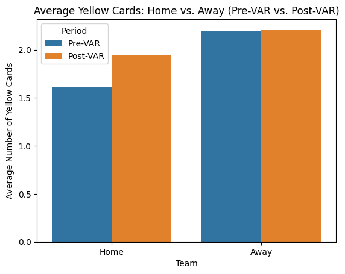

```python
data = pd.DataFrame({'Period': ['Pre-VAR', 'Pre-VAR', 'Post-VAR', 'Post-VAR'],
                     'Team': ['Home', 'Away', 'Home', 'Away'],
                     'Yellow Cards': [pre_var_merged['Home_Yellow_Cards'].mean(),
                                      pre_var_merged['Away_Yellow_Cards'].mean(),
                                      post_var_merged['Home_Yellow_Cards'].mean(),
                                      post_var_merged['Away_Yellow_Cards'].mean()]})

# Creates a grouped barplot of comparing average yellow cards of Home and Away teams in both Pre-VAR and Post-VAR periods
sns.barplot(data=data, x='Team', y='Yellow Cards', hue='Period')
plt.title('Average Yellow Cards: Home vs. Away (Pre-VAR vs. Post-VAR)')
plt.ylabel('Average Number of Yellow Cards')
plt.show()
```

The graph shows that the average number of yellow cards given to home teams increased slightly after the introduction of VAR, while the average for away teams remained virtually unchanged.

This suggests VAR may have reduced the home team's advantage in disciplinary decisions.

#### T-Test: Is there a significant difference in Average Yellow Cards difference (Home - Away) in Pre-VAR and Post-VAR periods?

```python
# Taking the difference of Yellow Cards (Home Yellows - Away Yellows) in both periods
pre_vals  = pre_var_merged['Home_Yellow_Cards'] - pre_var_merged['Away_Yellow_Cards']
post_vals = post_var_merged['Home_Yellow_Cards'] - post_var_merged['Away_Yellow_Cards']

# Running the t-test to get p-value
t_stat, p_val = ttest_ind(pre_vals, post_vals, equal_var=False)
print(f"Pre-VAR mean={pre_vals.mean():.2f}, Post-VAR mean={post_vals.mean():.2f}, p={p_val:.3g}")
```

```
Pre-VAR mean=-0.58, Post-VAR mean=-0.26, p=2.34e-06
```

#### Grouped-Bar Plot: Average Red Cards for Home and Away in Pre-VAR and Post-VAR periods

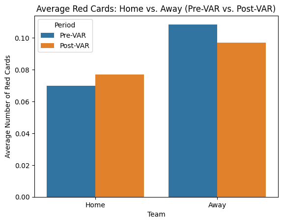

```python
data = pd.DataFrame({'Period': ['Pre-VAR', 'Pre-VAR', 'Post-VAR', 'Post-VAR'],
                     'Team': ['Home', 'Away', 'Home', 'Away'],
                     'Red Cards': [pre_var_merged['Home_Red_Cards'].mean(),
                                      pre_var_merged['Away_Red_Cards'].mean(),
                                      post_var_merged['Home_Red_Cards'].mean(),
                                      post_var_merged['Away_Red_Cards'].mean()]})

# Creates a grouped barplot of comparing average red cards of Home and Away teams in both Pre-VAR and Post-VAR periods
sns.barplot(data=data, x='Team', y='Red Cards', hue='Period')
plt.title('Average Red Cards: Home vs. Away (Pre-VAR vs. Post-VAR)')
plt.ylabel('Average Number of Red Cards')
plt.show()
```

This graph shows that after the introduction of VAR, the average number of red cards issued to home teams increased slightly, while the average for away teams decreased.

This suggests that VAR may have helped balance red card decisions more evenly between home and away teams.

#### T-Test: Is there a significant difference in Average Red Cards difference (Home - Away) in Pre-VAR and Post-VAR periods?

```python
# Taking the difference of Red Cards (Home Reds - Away Reds) in both periods
pre_vals  = pre_var_merged['Home_Red_Cards'] - pre_var_merged['Away_Red_Cards']
post_vals = post_var_merged['Home_Red_Cards'] - post_var_merged['Away_Red_Cards']

# Running the t-test to get p-value
t_stat, p_val = ttest_ind(pre_vals, post_vals, equal_var=False)
print(f"Pre-VAR mean={pre_vals.mean():.2f}, Post-VAR mean={post_vals.mean():.2f}, p={p_val:.3g}")
```

```
Pre-VAR mean=-0.04, Post-VAR mean=-0.02, p=0.23
```

#### Grouped-Bar Plot: Average Fouls for Home and Away in Pre-VAR and Post-VAR periods

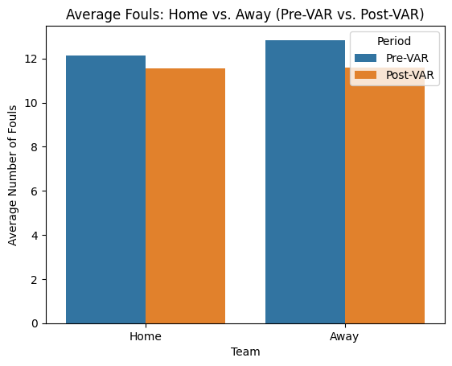

```python
data = pd.DataFrame({'Period': ['Pre-VAR', 'Pre-VAR', 'Post-VAR', 'Post-VAR'],
                     'Team': ['Home', 'Away', 'Home', 'Away'],
                     'Fouls': [pre_var_merged['Home_Fouls'].mean(),
                                      pre_var_merged['Away_Fouls'].mean(),
                                      post_var_merged['Home_Fouls'].mean(),
                                      post_var_merged['Away_Fouls'].mean()]})

# Creates a grouped barplot of comparing average fouls of Home and Away teams in both Pre-VAR and Post-VAR periods
sns.barplot(data=data, x='Team', y='Fouls', hue='Period')
plt.title('Average Fouls: Home vs. Away (Pre-VAR vs. Post-VAR)')
plt.ylabel('Average Number of Fouls')
plt.show()
```

The graph shows that both home and away teams committed fewer fouls on average after the introduction of VAR. This suggests that VAR may have led to more cautious play and greater discipline across both groups.

#### T-Test: Is there a significant difference in Average Fouls difference (Home - Away) in Pre-VAR and Post-VAR periods?

```python
# Taking the difference of Fouls (Home Fouls - Away Fouls) in both periods
pre_vals  = pre_var_merged['Home_Fouls'] - pre_var_merged['Away_Fouls']
post_vals = post_var_merged['Home_Fouls'] - post_var_merged['Away_Fouls']

# Running the t-test to get p-value
# Disclaimer: Foul data only is from 2015 onwards- may be unreliable with fewer rows
t_stat, p_val = ttest_ind(pre_vals.dropna(), post_vals.dropna(), equal_var=False)
print(f"Pre-VAR mean={pre_vals.mean():.2f}, Post-VAR mean={post_vals.mean():.2f}, p={p_val:.3g}")
```

```
Pre-VAR mean=-0.70, Post-VAR mean=-0.05, p=0.0393
```

#### Time-Series Line Plot: Average Number of Yellow Cards, Red Cards, and Fouls for Home and Away over the years

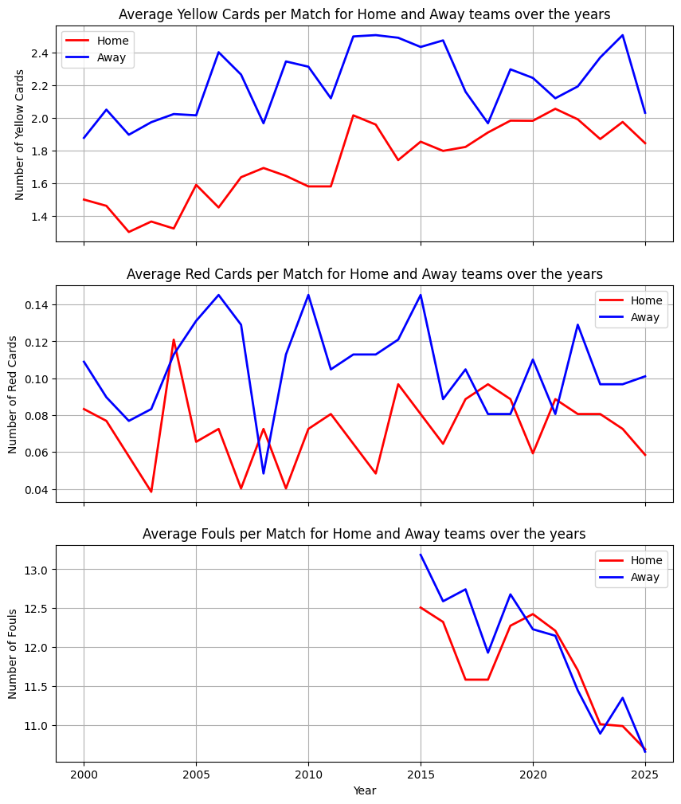

```python
# Put the data together and Groupby Season_End_Year to find yearly averages of cards and fouls
data = pd.concat([pre_var_merged, post_var_merged])
data = data.groupby('Season_End_Year')[['Home_Yellow_Cards', 'Away_Yellow_Cards',
                                       'Home_Red_Cards', 'Away_Red_Cards',
                                       'Home_Fouls', 'Away_Fouls']].mean().reset_index()

# Create 3 subplots with shared x-axis displaying years (2000-2025)
fig, axes = plt.subplots(3, 1, figsize=(10, 12), sharex=True)

# Time series plot to compared Home and Away Yellow cards
axes[0].plot(data['Season_End_Year'], data['Home_Yellow_Cards'], label='Home', color='red', linewidth=2)
axes[0].plot(data['Season_End_Year'], data['Away_Yellow_Cards'], label='Away', color='blue', linewidth=2)
axes[0].set_title('Average Yellow Cards per Match for Home and Away teams over the years')
axes[0].set_ylabel('Number of Yellow Cards')
axes[0].grid(True)
axes[0].legend()

# Time series plot to compared Home and Away Red cards
axes[1].plot(data['Season_End_Year'], data['Home_Red_Cards'], label='Home', color='red', linewidth=2)
axes[1].plot(data['Season_End_Year'], data['Away_Red_Cards'], label='Away', color='blue', linewidth=2)
axes[1].set_title('Average Red Cards per Match for Home and Away teams over the years')
axes[1].set_ylabel('Number of Red Cards')
axes[1].grid(True)
axes[1].legend()

# Time series plot to compared Home and Away Fouls
axes[2].plot(data['Season_End_Year'], data['Home_Fouls'], label='Home', color='red', linewidth=2)
axes[2].plot(data['Season_End_Year'], data['Away_Fouls'], label='Away', color='blue', linewidth=2)
axes[2].set_title('Average Fouls per Match for Home and Away teams over the years')
axes[2].set_ylabel('Number of Fouls')
axes[2].set_xlabel('Year')
axes[2].grid(True)
axes[2].legend()

plt.show()
```

### These three time-series plots show trends in disciplinary statistics for home and away teams from around 2000 to 2025:

#### Yellow Cards (Top Plot):

Away teams consistently receive more yellow cards than home teams. However, the gap narrows slightly after around 2017, which may align with the introduction of VAR.

#### Red Cards (Middle Plot):

Red cards show more fluctuation, but away teams generally receive more red cards than home teams. There's a slight convergence in recent years, suggesting a reduction in disparity.

### Overall, these trends support the idea that VAR may have contributed to reducing bias and encouraging more disciplined behavior from both home and away teams.

## A Fairer Analysis of Refereeing Bias: Accounting Confounding Variables

From the previous section we found out that there is a significant difference in the decisions made by the referee, especially when it comes to handing out cards. It's likely that referee is biased towards Home teams when giving out cards to players. However, this isn't a fair analysis as we didn't consider other factors in the game like score, strength of teams, possession, etc.

```python
# loading libraries from my system.
#import sys
#!{sys.executable} -m pip install statsmodels
```

```python
from scipy.stats import linregress
import statsmodels.api as sm
import statsmodels.formula.api as smf
from sklearn.preprocessing import StandardScaler
```

#### Scatter Plot and Trendline: Relationship between Goal Difference (Home - Away) and Home and Away Yellow Cards

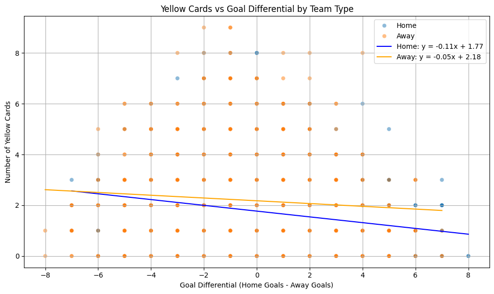

```python
# merging the two datasets together and calculating goals difference
data = pd.concat([pre_var_merged, post_var_merged])
goal_diff = data['Home_Score'] - data['Away_Score']

data = pd.DataFrame({'goal_diff': pd.concat([goal_diff, -1*goal_diff]),  # invert for away team
                     'yellows': pd.concat([data['Home_Yellow_Cards'], data['Away_Yellow_Cards']]),
                     'team': ['Home'] * len(data) + ['Away'] * len(data)}) # because we're unstacking the data by pd.concat (first n is Home, then Away)

plt.figure(figsize=(10, 6))

# Scatter points
sns.scatterplot(data=data, x='goal_diff', y='yellows', hue='team', alpha=0.5)

# Fitting regression line for Home Team
home_df = data[data['team'] == 'Home']
slope_h, intercept_h, r_value, p_value, std_err = linregress(home_df['goal_diff'], home_df['yellows'])
x_vals = pd.Series(sorted(home_df['goal_diff']))
plt.plot(x_vals, intercept_h + slope_h * x_vals, label=f"Home: y = {slope_h:.2f}x + {intercept_h:.2f}", color='blue')

# Fitting regression line for Away Team
away_df = data[data['team'] == 'Away']
slope_a, intercept_a, r_value, p_value, std_err = linregress(away_df['goal_diff'], away_df['yellows'])
x_vals = pd.Series(sorted(away_df['goal_diff']))
plt.plot(x_vals, intercept_a + slope_a * x_vals, label=f"Away: y = {slope_a:.2f}x + {intercept_a:.2f}", color='orange')

plt.title('Yellow Cards vs Goal Differential by Team Type')
plt.xlabel('Goal Differential (Home Goals - Away Goals)')
plt.ylabel('Number of Yellow Cards')
plt.legend()
plt.grid(True)
plt.tight_layout()
plt.show()
```

This scatter plot shows a negative relationship between goal differential and the number of yellow cards for both home and away teams.

In simple terms, teams that win by more goals tend to receive fewer yellow cards.

The relationship is slightly stronger for home teams (slope = -0.11) compared to away teams (slope = -0.05), suggesting that as home teams dominate matches more, their likelihood of receiving yellow cards decreases more noticeably.

#### Permutation Test: Is there a significant difference in Home and Away Yellow Cards, accounting for the scorline?

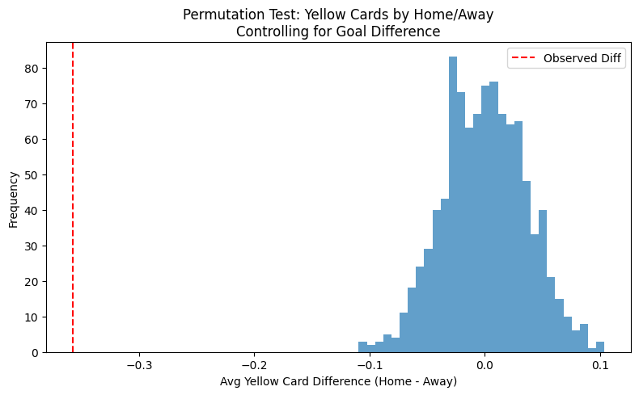

```
Observed Difference in Yellow Cards (accounting for Goal Difference): -0.3577
Permutation p-value: 0.0000
```

```python
# merging the two datasets together and calculating goals difference
data = pd.concat([pre_var_merged, post_var_merged])
goal_diff = data['Home_Score'] - data['Away_Score']

data = pd.DataFrame({'goal_diff': pd.concat([goal_diff, -1*goal_diff]),
                     'yellows': pd.concat([data['Home_Yellow_Cards'], data['Away_Yellow_Cards']]),
                     'team': ['Home'] * len(data) + ['Away'] * len(data)})

data['bin'] = pd.qcut(data['goal_diff'], q=5, duplicates='drop')  # 5 bins by goal_diff

# Observed difference in Yellow cards in Home and Away
obs_diff_goal = (
    data[data['team'] == 'Home'].groupby('bin', observed=False)['yellows'].mean() -
    data[data['team'] == 'Away'].groupby('bin', observed=False)['yellows'].mean()
).mean()

# Running the permutation test
perm_diffs_goal = []
for _ in range(1000):
    shuffled = data.copy()
    shuffled['team'] = shuffled.groupby('bin', observed=False)['team'].transform(np.random.permutation)
    perm_diff = (
        shuffled[shuffled['team'] == 'Home'].groupby('bin', observed=False)['yellows'].mean() -
        shuffled[shuffled['team'] == 'Away'].groupby('bin', observed=False)['yellows'].mean()
    ).mean()
    perm_diffs_goal.append(perm_diff)

# Calculating the p-value
perm_diffs_goal = np.array(perm_diffs_goal)
p_val_goal = (np.abs(perm_diffs_goal) >= np.abs(obs_diff_goal)).mean()

# Graphing the distribution of Yellow Card differences vs the observed test statistic
plt.figure(figsize=(8, 5))
plt.hist(perm_diffs_goal, bins=30, alpha=0.7)
plt.axvline(obs_diff_goal, color='red', linestyle='--', label='Observed Diff')
plt.title('Permutation Test: Yellow Cards by Home/Away\nControlling for Goal Difference')
plt.xlabel('Avg Yellow Card Difference (Home - Away)')
plt.ylabel('Frequency')
plt.legend()
plt.tight_layout()
plt.show()

print(f"Observed Difference in Yellow Cards (accounting for Goal Difference): {obs_diff_goal:.4f}")
print(f"Permutation p-value: {p_val_goal:.4f}")
```

This permutation test histogram shows the distribution of average yellow card differences (Home − Away) under the null hypothesis, controlling for goal differential.

The red dashed line represents the actual observed difference, which lies far in the left tail of the distribution.

This indicates that home teams receive significantly fewer yellow cards than away teams, even after accounting for goal differential; **suggesting a statistically significant bias or advantage for home teams.**

#### Line plot: Average Home and Yellow Cards across all UEFA Club Coefficients Difference between Teams

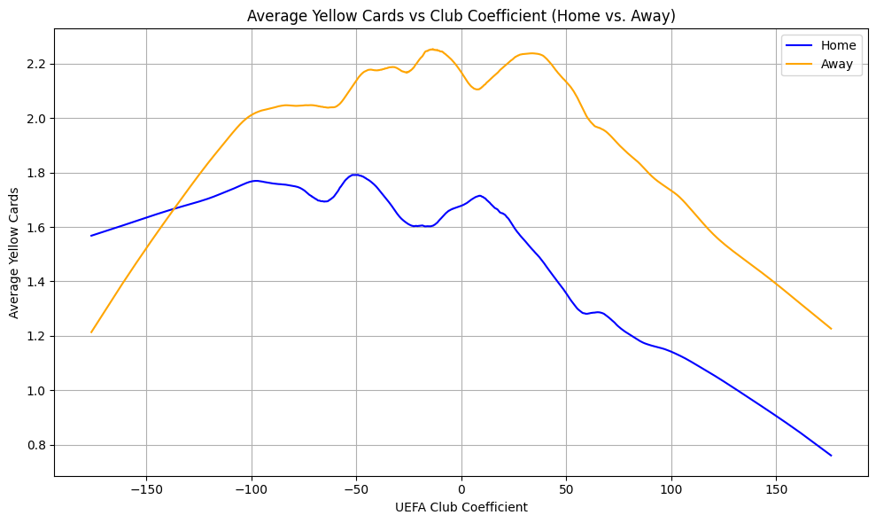

```python
# merging the two datasets together and calculating the coefficient difference
data = pd.concat([pre_var_merged, post_var_merged])
coef_diff = data['Home_Coefficient'] - data['Away_Coefficient']

data = pd.DataFrame({'yellows': pd.concat([data['Home_Yellow_Cards'], data['Away_Yellow_Cards']]),
                     'coef': pd.concat([coef_diff, -1*coef_diff]),
                     'team': ['Home'] * len(data) + ['Away'] * len(data)}) # because we're unstacking the data by pd.concat (first n is Home, then Away)

plt.figure(figsize=(10, 6))

# LOWESS for Home
home_df = data[data['team'] == 'Home']
lowess_home = sm.nonparametric.lowess(home_df['yellows'], home_df['coef'], frac=0.2)
plt.plot(lowess_home[:, 0], lowess_home[:, 1], label='Home', color='blue')

# LOWESS for Away
away_df = data[data['team'] == 'Away']
lowess_away = sm.nonparametric.lowess(away_df['yellows'], away_df['coef'], frac=0.2)
plt.plot(lowess_away[:, 0], lowess_away[:, 1], label='Away', color='orange')

plt.title('Average Yellow Cards vs Club Coefficient (Home vs. Away)')
plt.xlabel('UEFA Club Coefficient')
plt.ylabel('Average Yellow Cards')
plt.grid(True)
plt.legend()
plt.tight_layout()
plt.show()
```

However, away teams consistently receive more yellow cards than home teams for most of the range of club strength. Only when the Home team has around 130 less UEFA club coefficient points than the away team (thus a very poor team in comparison), they tend to get more Yellow Cards. This highlights a disciplinary disadvantage for away teams in most equal matchups.

#### Permutation Test: Is there a significant difference in Home and Away Yellow Cards, accounting for UEFA Club Coefficient?

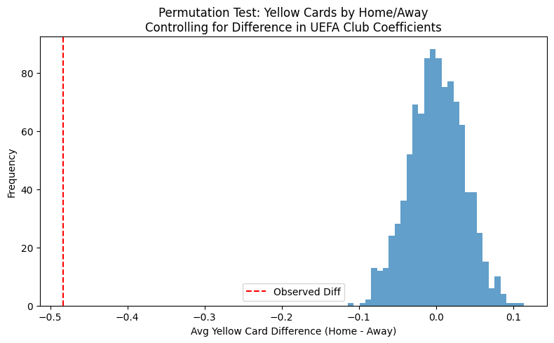

```
Observed Difference in Yellow Cards (accounting for Club Coefficients): -0.4835
Permutation p-value: 0.0000
```

```python
# merging the two datasets together and calculating goals difference
data = pd.concat([pre_var_merged, post_var_merged])
coef_diff = data['Home_Coefficient'] - data['Away_Coefficient']

data = pd.DataFrame({'coef_diff': pd.concat([coef_diff, -1*coef_diff]),
                     'yellows': pd.concat([data['Home_Yellow_Cards'], data['Away_Yellow_Cards']]),
                     'team': ['Home'] * len(data) + ['Away'] * len(data)})

data['bin'] = pd.qcut(data['coef_diff'], q=5, duplicates='drop')  # 5 bins by coef_diff

# Observed difference in Yellow cards in Home and Away
obs_diff_goal = (
    data[data['team'] == 'Home'].groupby('bin', observed=False)['yellows'].mean() -
    data[data['team'] == 'Away'].groupby('bin', observed=False)['yellows'].mean()
).mean()

# Running the permutation test
perm_diffs_goal = []
for _ in range(1000):
    shuffled = data.copy()
    shuffled['team'] = shuffled.groupby('bin', observed=False)['team'].transform(np.random.permutation)
    perm_diff = (
        shuffled[shuffled['team'] == 'Home'].groupby('bin', observed=False)['yellows'].mean() -
        shuffled[shuffled['team'] == 'Away'].groupby('bin', observed=False)['yellows'].mean()
    ).mean()
    perm_diffs_goal.append(perm_diff)

# Calculating the p-value
perm_diffs_goal = np.array(perm_diffs_goal)
p_val_goal = (np.abs(perm_diffs_goal) >= np.abs(obs_diff_goal)).mean()

# Graphing the distribution of Yellow Card differences vs the observed test statistic
plt.figure(figsize=(8, 5))
plt.hist(perm_diffs_goal, bins=30, alpha=0.7)
plt.axvline(obs_diff_goal, color='red', linestyle='--', label='Observed Diff')
plt.title('Permutation Test: Yellow Cards by Home/Away\nControlling for Difference in UEFA Club Coefficients')
plt.xlabel('Avg Yellow Card Difference (Home - Away)')
plt.ylabel('Frequency')
plt.legend()
plt.tight_layout()
plt.show()

print(f"Observed Difference in Yellow Cards (accounting for Club Coefficients): {obs_diff_goal:.4f}")
print(f"Permutation p-value: {p_val_goal:.4f}")
```

This permutation test shows the distribution of average yellow card differences (Home − Away) while controlling for differences in UEFA club coefficients.

The observed difference (red dashed line) is far to the left of the null distribution, indicating that home teams receive significantly fewer yellow cards than away teams—even after adjusting for team strength.

**This strongly suggests a consistent home advantage in yellow card decisions that is not explained by club quality.**

#### Linear Regression Model: Can we accurately determine number of Yellow Cards with features?

By training a linear regression model with standardized features like Home/Away Status, Home/Away goals scored, club coefficients, and match date, we can observe the relative sizes of the coefficients and the p-value to understand the importance of these features (and which one is the most deterministic)

```python
# merging the two datasets together and calculating the coefficient difference
data = pd.concat([pre_var_merged, post_var_merged])
coef_diff = data['Home_Coefficient'] - data['Away_Coefficient']
goal_diff = data['Home_Score'] - data['Away_Score']

data = pd.DataFrame({'yellows': pd.concat([data['Home_Yellow_Cards'], data['Away_Yellow_Cards']]),
                     'goal_diff': pd.concat([goal_diff, -1*goal_diff]),
                     'coef_diff': pd.concat([coef_diff, -1*coef_diff]),
                     'season': pd.concat([data['Season_End_Year'], data['Season_End_Year']]),
                     'team': ['Home'] * len(data) + ['Away'] * len(data)})


# One-Hot Encode the team status: Home = 1, Away = 0
data['is_home'] = data['team'].apply(lambda x: 1 if x == 'Home' else 0)

# Features to use in the model and scale
features = ['is_home',
            'goal_diff',
            'coef_diff',
            'season',
            'yellows']

# Scaling all features in order to find relative importance in predictions
data = data[features]
scaler = StandardScaler()
data[features] = scaler.fit_transform(data[features])

# Fitting a linear regression and printing the summary
res_1 = smf.ols(formula='yellows ~ is_home + goal_diff + coef_diff + season', data=data).fit()
res_1.summary()
```

OLS Regression Results

| Dep. Variable: | yellows | R-squared: | 0.053 |
| --- | --- | --- | --- |
| Model: | OLS | Adj. R-squared: | 0.052 |
| Method: | Least Squares | F-statistic: | 94.37 |
| Date: | Wed, 11 Jun 2025 | Prob (F-statistic): | 3.02e-78 |
| Time: | 23:47:37 | Log-Likelihood: | -9487.7 |
| No. Observations: | 6816 | AIC: | 1.899e+04 |
| Df Residuals: | 6811 | BIC: | 1.902e+04 |
| Df Model: | 4 |  |  |
| Covariance Type: | nonrobust |  |  |

|  | coef | std err | t | P>\|t\| | [0.025 | 0.975] |
| --- | --- | --- | --- | --- | --- | --- |
| Intercept | -4.58e-16 | 0.012 | -3.88e-14 | 1.000 | -0.023 | 0.023 |
| is_home | -0.1457 | 0.012 | -11.967 | 0.000 | -0.170 | -0.122 |
| goal_diff | -0.0979 | 0.014 | -7.204 | 0.000 | -0.125 | -0.071 |
| coef_diff | -0.0435 | 0.013 | -3.278 | 0.001 | -0.069 | -0.017 |
| season | 0.0986 | 0.012 | 8.362 | 0.000 | 0.076 | 0.122 |

| Omnibus: | 614.032 | Durbin-Watson: | 1.984 |
| --- | --- | --- | --- |
| Prob(Omnibus): | 0.000 | Jarque-Bera (JB): | 821.233 |
| Skew: | 0.757 | Prob(JB): | 4.69e-179 |
| Kurtosis: | 3.775 | Cond. No. | 1.73 |

Notes:  
[1] Standard Errors assume that the covariance matrix of the errors is correctly specified.

## A deeper analysis into the "Ghost Year" (2019/2020 Season during the COVID-19 pandemic)

As mentioned in our background research, the UEFA Champions League Games during the COVID-19 Pandemic didn't allow the fans to enter the stadium, creating "ghost games". Research shows that this majorly affected the refereeing decisions. In this section, statistics during this timeframe will be uncovered. This lasted from March 9th 2020 to October 1st 2020.

```python
post_var_merged['Date'] = pd.to_datetime(post_var_merged['Date'])

start_date = pd.Timestamp('2020-03-09')
end_date = pd.Timestamp('2020-10-01')

ghost_games = post_var_merged[(post_var_merged['Date'] >= start_date) & (post_var_merged['Date'] < end_date)]
ghost_games.tail()
```

|  | League | Matchweek | Home_Team | Home_Formation | Home_Score | Home_xG | Home_Goals | Home_Yellow_Cards | Home_Red_Cards | Away_Team | ... | Home_Goal_Kicks | Home_Throw_Ins | Home_Long_Balls | Away_Touches | Away_Tackles | Away_Aerials_Won | Away_Clearances | Away_Goal_Kicks | Away_Throw_Ins | Away_Long_Balls |
| --- | --- | --- | --- | --- | --- | --- | --- | --- | --- | --- | --- | --- | --- | --- | --- | --- | --- | --- | --- | --- | --- |
| 361 | UEFA Champions League | UEFA Champions League (Quarter-finals) | RB Leipzig | 4-2-3-1 | 2 | 0.9 | Dani Olmo · 50&rsquor; Tyler Adams · 88&rsquor; | 3 | 0 | Atlético Madrid | ... | 5.0 | 17.0 | 77.0 | 603.0 | 9.0 | 23.0 | 22.0 | 6.0 | 22.0 | 56.0 |
| 362 | UEFA Champions League | UEFA Champions League (Quarter-finals) | FC Barcelona | 4-4-2 | 2 | 1.1 | David Alaba (OG) · 7&rsquor; Luis Suárez · 57&... | 3 | 0 | Bayern München | ... | 11.0 | 10.0 | 57.0 | 576.0 | 11.0 | 12.0 | 14.0 | 1.0 | 12.0 | 52.0 |
| 363 | UEFA Champions League | UEFA Champions League (Quarter-finals) | Manchester City | 3-4-3 | 1 | 2.5 | Kevin De Bruyne · 69&rsquor; | 2 | 0 | Lyon | ... | 1.0 | 24.0 | 59.0 | 397.0 | 16.0 | 9.0 | 26.0 | 12.0 | 15.0 | 74.0 |
| 364 | UEFA Champions League | UEFA Champions League (Semi-finals) | RB Leipzig | 4-1-4-1 | 0 | 1.0 | No Scorers | 3 | 0 | Paris Saint-Germain | ... | 6.0 | 19.0 | 54.0 | 812.0 | 9.0 | 12.0 | 32.0 | 6.0 | 17.0 | 44.0 |
| 365 | UEFA Champions League | UEFA Champions League (Semi-finals) | Lyon | 3-5-2 | 0 | 1.8 | No Scorers | 3 | 0 | Bayern München | ... | 6.0 | 25.0 | 70.0 | 796.0 | 24.0 | 14.0 | 16.0 | 6.0 | 17.0 | 68.0 |

5 rows × 53 columns

#### Statistics for Refereeing Bias Metrics

```python
ghost_games[['Home_Yellow_Cards', 'Home_Red_Cards', 'Home_Fouls', 'Away_Yellow_Cards', 'Away_Red_Cards', 'Away_Fouls']].describe()
```

|  | Home_Yellow_Cards | Home_Red_Cards | Home_Fouls | Away_Yellow_Cards | Away_Red_Cards | Away_Fouls |
| --- | --- | --- | --- | --- | --- | --- |
| count | 14.000000 | 14.0 | 14.000000 | 14.000000 | 14.000000 | 14.000000 |
| mean | 2.500000 | 0.0 | 15.142857 | 2.214286 | 0.071429 | 13.214286 |
| std | 1.743118 | 0.0 | 6.407413 | 1.717716 | 0.267261 | 5.071467 |
| min | 0.000000 | 0.0 | 8.000000 | 0.000000 | 0.000000 | 3.000000 |
| 25% | 1.250000 | 0.0 | 12.000000 | 1.000000 | 0.000000 | 12.000000 |
| 50% | 2.500000 | 0.0 | 13.000000 | 2.000000 | 0.000000 | 13.000000 |
| 75% | 3.000000 | 0.0 | 20.000000 | 2.750000 | 0.000000 | 17.000000 |
| max | 6.000000 | 0.0 | 29.000000 | 7.000000 | 1.000000 | 22.000000 |

#### T-Test: Is the significant difference in Home and Away Yellow Cards, Red Cards, and Fouls during the ghost games compared to the rest of the Post-VAR period?

First let's look at the distribution of Yellow Cards:

```python
yellows_diff = post_var_merged['Home_Yellow_Cards'] - post_var_merged['Away_Yellow_Cards']
ghost_yellows_diff = ghost_games['Home_Yellow_Cards'] - ghost_games['Away_Yellow_Cards']

t_stat, p_val = ttest_ind(ghost_yellows_diff, yellows_diff, equal_var=False)

print(f"Welch’s t-test:\nT-stat = {t_stat:.4f}, p = {p_val:.4f}")
```

```
Welch’s t-test:
T-stat = 0.8475, p = 0.4118
```

Now let's analyse the distribution of Red Cards.

```python
reds_diff = post_var_merged['Home_Red_Cards'] - post_var_merged['Away_Red_Cards']
ghost_reds_diff = ghost_games['Home_Red_Cards'] - ghost_games['Away_Red_Cards']

t_stat, p_val = ttest_ind(ghost_reds_diff, reds_diff, equal_var=False)

print(f"Welch’s t-test:\nT-stat = {t_stat:.4f}, p = {p_val:.4f}")
```

```
Welch’s t-test:
T-stat = -0.7087, p = 0.4903
```

Lastly, we'll work with the distribution of Fouls.

```python
fouls_diff = post_var_merged['Home_Fouls'] - post_var_merged['Away_Fouls']
ghost_fouls_diff = ghost_games['Home_Fouls'] - ghost_games['Away_Fouls']

t_stat, p_val = ttest_ind(ghost_fouls_diff, fouls_diff, equal_var=False)

print(f"Welch’s t-test:\nT-stat = {t_stat:.4f}, p = {p_val:.4f}")
```

```
Welch’s t-test:
T-stat = 0.9716, p = 0.3487
```

# Ethics & Privacy

In this project, we used publicly available match data from FBRef and UEFA coefficient archives to explore whether home teams in the UEFA Champions League have continued to benefit from referee decisions after the introduction of VAR in 2018. All of the data we worked with was at the team level and did not include any personal or private player information. We made sure to use open-access sources only and avoided any platforms that restrict how their data can be used or shared. If we ever had doubts about the source of a dataset, we either found an alternative or left it out entirely. A major ethical concern we considered is the bias that can exist within the data itself. Most football datasets focus on men's competitions, which means that women's football is often left out. For example, the UEFA Women's Champions League is not included in our analysis because the data is limited and VAR has only recently been introduced in that tournament. This means our findings only reflect trends in men's football, and we want to be clear about that limitation. Another issue we noticed was that early VAR data may be inconsistent or missing for some matches. To handle this, we filtered out matches that lacked complete information or seemed unreliable and were transparent about where those gaps existed.

Throughout the project, we used Deon's Ethics Checklist to guide our decisions at each stage, from framing our research question to collecting, analyzing, and presenting the data. We aimed to interpret our results responsibly, which means that we stayed cautious about what the data supports and avoided drawing conclusions that go beyond the scope of our analysis. Rather than assigning blame or assuming bad intent from referees or teams, we focused on identifying statistical patterns in disciplinary outcomes. Our goal was to use data science tools to explore these trends thoughtfully and to communicate our findings in a way that is fair, measured, and respectful to everyone involved in the sport.

# Discusison and Conclusion

This study aimed to investigate whether refereeing bias in favor of home teams in the UEFA Champions League has decreased since the implementation of Video Assistant Referee (VAR) technology in 2018. Looking at prior work that has documented persistent home-field advantages—especially in terms of disciplinary decisions like fouls, cards, and penalties—like game statistics datasets, we tried to determine if VAR has helped make games fairer, or if the biases remain in place.

Regarding fouls, both home and away teams showed a downward trend in the number over time, especially after 2015 and continuing into the post-VAR era. The t-test comparing average foul amounts (Home - Away) pre- (mean=-0.70) and post-VAR (mean=-0.05) showed a significant reduction in the difference (p=0.0393). Given our chosen threshold of p=0.05, this supports either the idea that VAR encouraged fairer officiating, or players were more inclined to be more disciplined, or both. This trend is also clear in time-series plots, where foul rates between home and away teams converge over time. The limitation of this analysis was that this didn't tell us where and how this discrepancy was arising, hence leading us to the next part of our project, which analyses possible confounding variables like goal differentials and UEFA club Coefficients.

When we consider "ghost games", though (matches played without spectators during the pandemic), they were a natural experiment that provided data controlling for crowd influence. However, our Welch's t-tests showed no statistically significant differences in yellow cards, red cards, or fouls between ghost games and the broader post-VAR era (p-values > 0.34). This shows that while fans might have had an impact on referee decisions, they couldn't have been responsible for a major amount of it, and that VAR itself (or other factors like changes in referee training) probably played a bigger part. However, one limitation of this analysis was the number of games in the "Ghost Games" dataframe, only 14 rows. This isn't enough data for one to infer a reliable trend, so we must take this conclusion with a pinch of salt.

In conclusion, our project data analysis supports the idea that VAR has moderated, but not eradicated, disciplinary bias in favor of home teams. Overall fairness seems to have improved, especially in foul and red card decisions, but yellow card disparities are still apparent even after dealing with the confounding factors like team strength. This suggests that while VAR is still a strong equalizing tool, to eradicate bias, it has to be paired with better referee training or even further automation or transparency when it comes to officiating. Future research might explore something like the psychological states of referees pre- and post-VAR, which could influence how they rule. One limitation in our overall project was the lack of access to VAR decisions in these games. Such a dataset would have told us the number of interferences VAR makes in each game, allowing us to understand whether and how it's involved. As football evolves with technology, strategies for ensuring fairness must evolve with it.

# Team Contributions

- Yash Tandon: Designed the scraping in RStudio and Python for all our Datasets. Contributed to the tidying and cleaning of the datasets. Cleaned up plots from the initial EDA to make them more interpretable. Identified possible confounding features and performed fairness analysis tests to test our hypothesis robustly.
- Madhav Singhvi: I contributed to all parts of the project, including ideation, researching, data collection, cleaning, analysis, and interpretation, as well as writing up our findings.
- Aubai Miralam: Contributed to all aspects, mainly the Ideation, EDA, and the video.
- Abhyuday Singh: I contributed to all parts of the project like EDA by creating and interpreting graphs, ideation and data wrangling/cleaning.
- Mitra Sutar: Performed the final analysis and wrote the conclusion and abstract. Contributed to the EDA as well as Ethics portion.